# Réorganisation des données avancée - solution des exercices

[Retour à la page d’accueil](https://scortijo.github.io/2021_L3_R/)

> **Exercice 1:**

> Créez une nouvelle colonne (blade.ratio) avec le ratio de `blade.length.mm` et `total.leaf.length.mm`

```r
mutate(expt1, blade.ratio=blade.length.mm/total.leaf.length.mm)
```

```
## # A tibble: 957 x 16
##    plant_nb genotype background temperature fluctuation day.length vernalization
##       <dbl> <chr>    <chr>            <dbl> <chr>            <dbl> <chr>
##  1        1 Col Ama  Col                 12 Con                 16 NV
##  2        2 Col Ama  Col                 12 Con                 16 NV
##  3        3 Col Ama  Col                 12 Con                 16 NV
##  4        4 Col Ama  Col                 12 Con                 16 NV
##  5        5 Col Ama  Col                 12 Con                 16 NV
##  6        6 Col Ama  Col                 12 Con                 16 NV
##  7        7 Col Ama  Col                 12 Con                 16 NV
##  8        8 Col Ama  Col                 12 Con                 16 NV
##  9        1 Col Ama  Col                 12 Con                  8 NV
## 10        2 Col Ama  Col                 12 Con                  8 NV
## # … with 947 more rows, and 9 more variables: survival.bolt <chr>, bolt <chr>,
## #   days.to.bolt <dbl>, days.to.flower <dbl>, rosette.leaf.num <dbl>,
## #   cauline.leaf.num <dbl>, blade.length.mm <dbl>, total.leaf.length.mm <dbl>,
## #   blade.ratio <dbl>
```

> **Exercice 2:**

> Reproduisez cette figure de [Burghard et al 2015](https://nph.onlinelibrary.wiley.com/doi/full/10.1111/nph.13799)

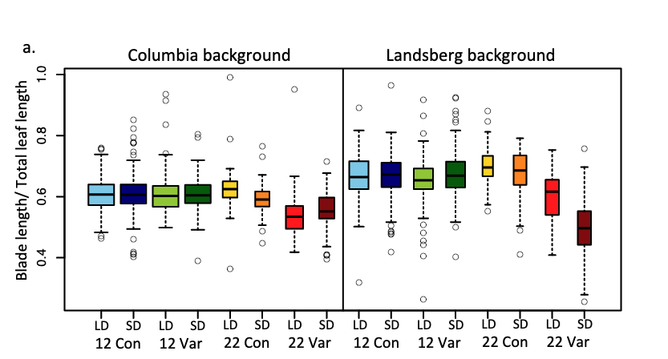

> Aide:
> - Créez une nouvelle colonne (blade.ratio) avec le ratio de `blade.length.mm` et `total.leaf.length.mm`
> - Créez une nouvelle colonne (nommée par exemple `condition`) en concaténant `day.length`, `temperature` et `fluctuation`
> - Sélectionnez les background `Col` et `Ler`
> - Faites un boxplot du ratio de `blade.length.mm` et `total.leaf.length.mm` en fonction de la `condition`, en créant des facets en fonction du background
> - Pas besoin de mettre de la couleur qui n’apporte rien au graphique
> - N’essayez pas de reproduire l’ordre des conditions (sur l’axe x). Nous verrons comment le faire à la prochaine séance

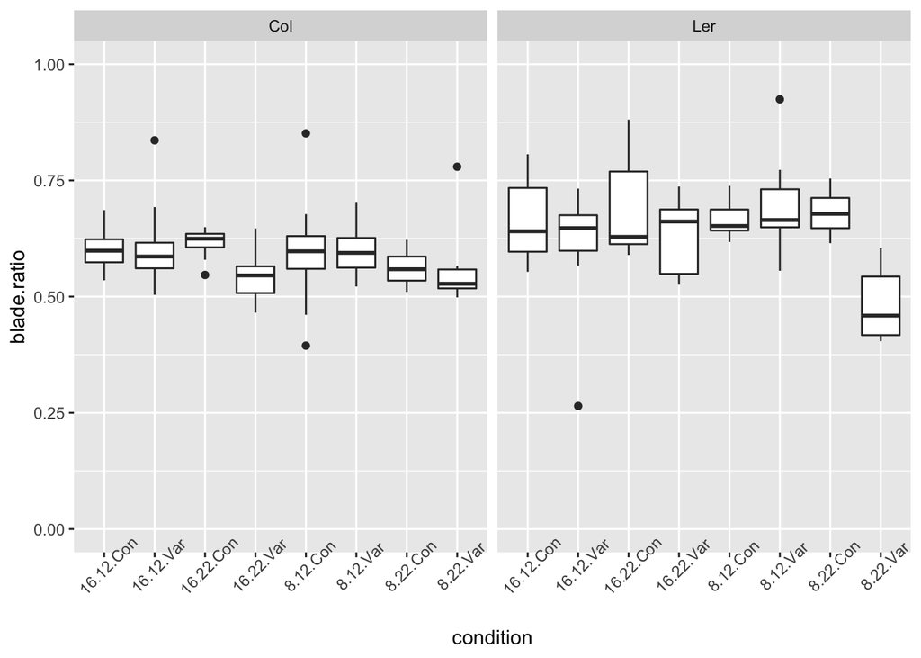

```r
mutate(expt1, blade.ratio=blade.length.mm/total.leaf.length.mm) %>%
  unite("condition", day.length, temperature, fluctuation, sep=".") %>%
  filter(background%in%c("Col","Ler")) %>%
  ggplot(aes(x=condition, y=blade.ratio)) +
  geom_boxplot()+
  ylim(0,1) +
  facet_grid(.~background) +
  theme(axis.text.x=element_text(angle = 45))
```

> **BONUS**: Ce bonus vous permettra d’avoir des valeurs de x plus proches du graphique
> - Avant de créer la nouvelle colonne en concaténant `day.length`, `temperature` et `fluctuation`, créer une colonne `LD.SD` dans laquelle vous aurez “LD” à la place de la valeur “16” de la colonne `day.length`, et “SD” à la place de la valeur “8” de la colonne `day.length`. Utilisez ensuite cette colonne `LD.SD` pour la concaténation avec `temperature` et `fluctuation` pour créer la colonne `condition`
> - Changez le thème du graphique pour enlever la grille et avoir un fond blanc.

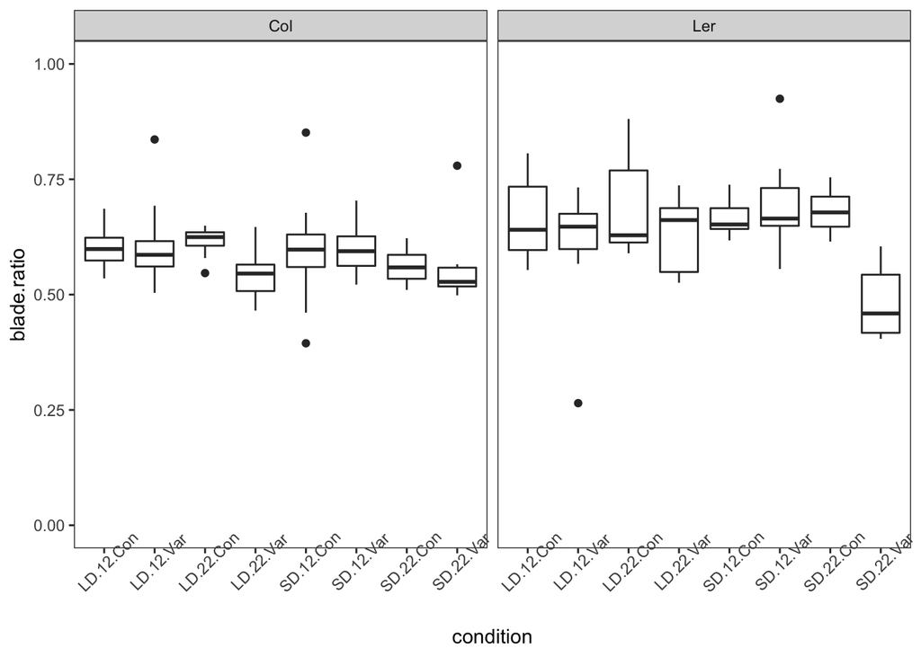

```r
mutate(expt1, blade.ratio=blade.length.mm/total.leaf.length.mm) %>%
  mutate(LD.SD=str_replace(day.length, "16","LD"),
         LD.SD=str_replace(LD.SD, "8","SD")) %>%
  unite("condition", LD.SD, temperature, fluctuation, sep=".") %>%
  filter(background%in%c("Col","Ler")) %>%
  ggplot(aes(x=condition, y=blade.ratio)) +
  geom_boxplot()+
  ylim(0,1) +
  facet_grid(.~background) +
  theme_bw() +
  theme(axis.text.x=element_text(angle = 45),
        panel.grid.major = element_blank(),
        panel.grid.minor = element_blank())
```

> **Exercice 3:**
> 1. Utilisez la fonction `gather()` pour restructurer le tableau afin de faire un boxplot de `blade.length.mm` et `total.leaf.length.mm`, coloré par `fluctuation`.
> 2. Ajoutez aux boxplots des encoches indiquant l’étendue de l’intervalle de confiance à 95% de la médiane (voir l’option `notch` dans `geom_boxplot`). Si les encoches sont étroite, il y a peu d’incertitude sur la médiane, si les encoches sont large, il y a une forte incertitude sur la médiane. Si les encoches de boxplots que nous comparons se chevauchent, alors nous ne pouvons pas conclure à une différence de médiane entre les médiane des deux groupes.

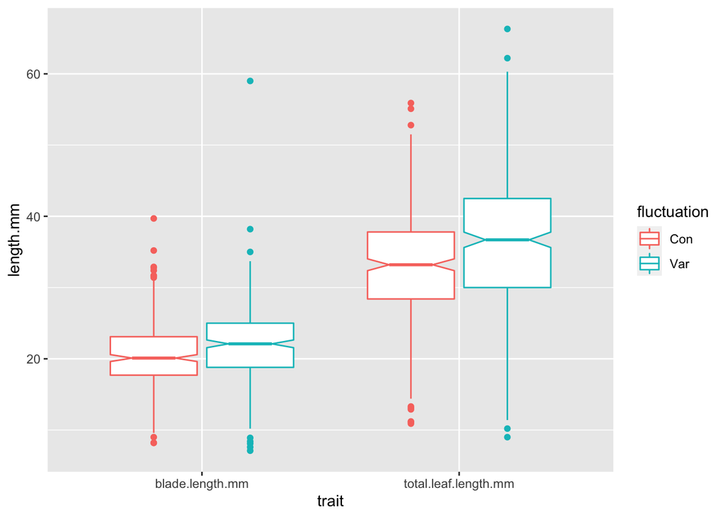

```r
gather(expt1, "trait", "length.mm", blade.length.mm, total.leaf.length.mm) %>%
  ggplot(aes(x=trait, y=length.mm, color=fluctuation)) +
  geom_boxplot(notch=TRUE)
```

> 3. Interprétez le graphique: Y a t’il un effet de la fluctuation de température sur la longueur de blade ou de la feuille? Pourquoi?

Sur le graphique nous observons que les valeurs des boxplots pour les plantes ayant poussé en condition de température variable sont plus élevée que pour les plantes ayant pousser en condition de température stable. Pour les longueurs de blade et de la feuille, la médiane est plus élevée en condition de température variable, et les encoches sont petites, indiquant une forte certitude de la valeur de médiane, et ne se chevauchent pas entre les deux conditions indiquant une différence de médiane entre les deux conditions. Ce graphique montre que les plantes poussant en condition de température variable ont une longueur de blade et une longueur totale de la feuille plus grande que en condition de température constante.

> **BONUS** Optimisez le graphique obtenu en jouant sur le thème, les couleurs utilisée (visibles par des daltoniens), le titre et la valeur des axes et de la légende, de manière à avoir un graphique similaire au graphique suivant:

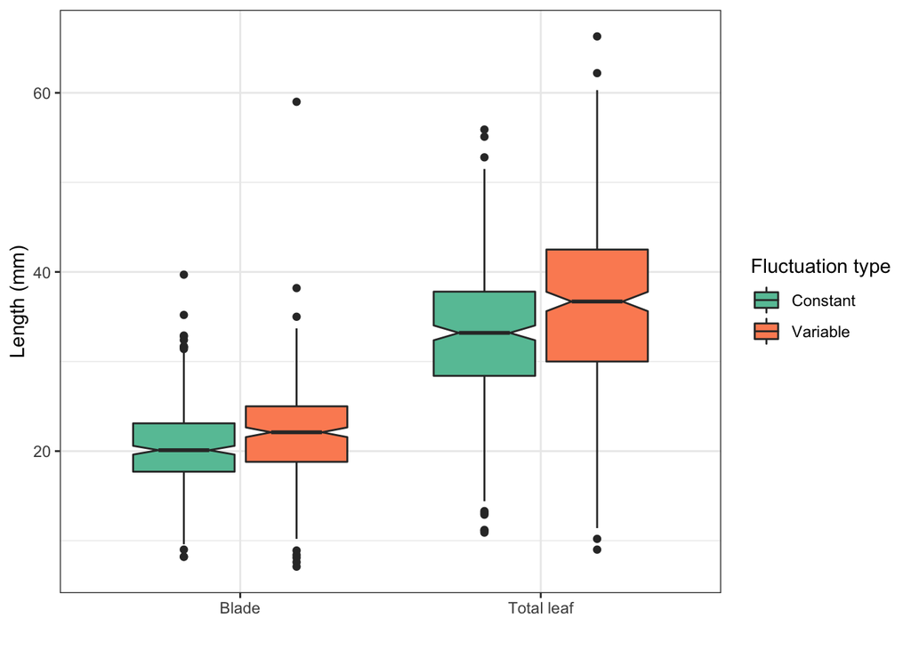

```r
gather(expt1, "trait", "length.mm", blade.length.mm, total.leaf.length.mm) %>%
  ggplot(aes(x=trait, y=length.mm, fill=fluctuation)) +
  geom_boxplot(notch = TRUE) +
  scale_fill_brewer(palette = "Set2", labels = c("Con"="Constant", "Var"="Variable"),
                    name="Fluctuation type") +
  theme_bw() +
  scale_x_discrete(name="",labels=c("blade.length.mm"="Blade","total.leaf.length.mm"="Total leaf")) +
  ylab("Length (mm)")
```